# MUSS: Spike and Slab Variable Selector under Matrix Uncertainty

Shuyu Guo

2022/12/8

In high-dimensional sparse regression model, `MUSS` is developed for the cases when variables of the design matrix contain additive measurement errors. More specifically, we assume that the measurement errors are Normally distributed with mean 0, and errors for each variable have a specific variance. Inspired by SSLASSO(Ročková and George 2018) and EMVS(Ročková and George 2014), here the spike and slab priors are assigned to regression parameter $\boldsymbol{\beta}$. `MUSS` works under EM framework, where the unknown true design matrix and indicators of spike-slab priors are treated as latent variables. To avoid the effect of inappropriate choices of spike and slab scale parameters on variable selection, the final output regression coefficients are obtained following a decreasing sequence of spike parameters, and the path can be displayed by function from `MUSS` package.

**Notice**: Verified from simulation experiments, this method works when all the variables include additive errors and the variances are within a reasonable range. Satisfying selection results are not guaranteed if inappropriate initial values are chosen.

# Model

## Additive Measurement Error

Suppose we have $n$ observations and $p$ potential predictors (possibly $p > n$ in high-dimensional case), then the ordinary linear regression model is
$$\boldsymbol{y} = X\boldsymbol{\beta} + \boldsymbol{\varepsilon},$$
where $X$ is the $n\times p$ design matrix and $\boldsymbol{\varepsilon}$ is the $i.i.d$ Gaussian model error with mean $0$ and variance $\sigma^2$.

Assume each column of $X$ is hidden behind independent additive measurement errors. That is, what we actually observe is the matrix $Z$:
$$Z = X + \Xi$$
where the elements of $\Xi$, measurement errors, are assumed to be independent Normal with mean $0$.

We use $\boldsymbol{z_i}$ and $\boldsymbol{x_i}$ to denote the row vectors of $Z$ and $X$. Specifically, each column $\Xi_{(,j)}$ has its corresponding variance $\tau_j$. Then the covariance matrix of each row $\Xi_{(i,)}$ is $\Lambda = diag(\tau_1, ..., \tau_d)$. Thus given the $i$th error-in-variable observation $\boldsymbol{z_i}$, $\boldsymbol{x_i} = \boldsymbol{z_i} - \Xi_{(i,)}$ has a multivariate normal distribution::
$$\boldsymbol{x_i}|\boldsymbol{z_i},\Lambda \sim MultiN(\boldsymbol{z_i},\Lambda)$$

## Parameter Priors

Inspired by `SSLASSO` and `EMVS`, we assume spike and slab priors for $\boldsymbol{\beta}$ to make variable selection. `EMVS` adopted Gaussian prior and `SSLASSO` adopted Laplacian prior. In `MUSS` algorithm, users can choose either Laplacian or Gaussian prior by setting parameter `beta_prior_type`.

$\gamma_j$ is a binary indicator implying whether $\beta_j$ has a spike prior($\gamma_j=0$) or a slab($\gamma_j=1$) prior. For Laplacian priors with $\lambda_0 < \lambda_1$,
$$\pi_L(\beta_j|\gamma_j=1) = \frac{1}{2\lambda_1} e^{-\frac{|\beta_j|}{\lambda_1}} \ (Slab) \ \ \ and \ \ \ \pi_L(\beta_j|\gamma_j=0) = \frac{1}{2\lambda_0} e^{-\frac{|\beta_j|}{\lambda_0 }} \ (Spike)$$

For Gaussian priors with $v_0 < v_1$,
$$\pi_G(\beta_j|\gamma_j=1) = \frac{1}{\sqrt{2\pi v_1}} e^{-\frac{\beta_j^2}{2v_1}} \ (Slab) \ \ \ and \ \ \ \pi_G(\beta_j|\gamma_j=0) = \frac{1}{\sqrt{2\pi v_0}} e^{-\frac{\beta_j^2}{2v_0}} \ (Spike)$$
Furthermore, it is assumed the prior of $\gamma_j$ is a Bernoulli distribution dependent on $\theta$:
$$\pi(\gamma_j|\theta) = \theta^{\gamma_j} (1-\theta)^{(1-\gamma_j)}$$
And $\theta$ has a Beta prior parameter $(a,b)$:
$$\pi(\theta) \propto \theta^{(a-1)} (1-\theta)^{(b-1)}$$
When $\sigma^2$ is unknown, an Inverse Gamma prior is set:
$$\sigma^2 \sim IG(\omega/2, \omega \kappa/2)\propto(\sigma^2)^{-\frac{\omega}{2}-1}e^{-\frac{\omega \kappa}{2\sigma^2}}$$

# EM Algorithm

Together with the likelihood
$$y_i|\boldsymbol{x}_i,\boldsymbol{\beta},\sigma^2 \sim N(\boldsymbol{x}_i^\top \boldsymbol{\beta},\sigma^2),$$
and because of posterior $\pi(\boldsymbol{\beta},\theta,\sigma^2|\boldsymbol{y},Z, \Lambda)\propto f(\boldsymbol{y},\boldsymbol{\beta},\theta,\sigma^2|Z, \Lambda)$, now our goal is to find maximizers $\boldsymbol{\beta}$, $\theta$,$\sigma$ for the objective function
$$\log f(\boldsymbol{y},\boldsymbol{\beta},\theta,\sigma^2|Z, \Lambda) = \sum_{i=1}^{n} \log \int f(y_i|\boldsymbol{x}_i^\top \boldsymbol{\beta},\sigma^2)f(\boldsymbol{x}_i|\boldsymbol{z}_i, \Lambda) d x_i \sum_{j=1}^{p} \log \sum_{\gamma_j=0}^{1}(\pi(\beta_j|\gamma_j) \pi(\gamma_j|\theta)) \pi(\theta) \pi(\sigma^2),$$
where EM algorithm can be applied and $X$ and $\boldsymbol{\gamma}$ are latent variables.

For **E-step**, by Jensen’s Inequality, we have
$$\begin{aligned}
\log f(\boldsymbol{y},\boldsymbol{\beta},\theta,\sigma^2| Z, \Lambda) &\geq g(\boldsymbol{\beta},\theta,\sigma^2 | \boldsymbol{\beta^{(t)}},\theta^{(t)}, (\sigma^2)^{(t)})\\
&= - \frac{1}{2\sigma^2} (\boldsymbol{y}^\top \boldsymbol{y} - 2\boldsymbol{y}^\top \widetilde X^{(t)} \boldsymbol{\beta}+ \boldsymbol{\beta}^\top \left[(\widetilde X^{(t)})^\top \widetilde X^{(t)} + n \widetilde \Sigma^{(t)}\right] \boldsymbol{\beta})+Pen^{(t)}(\boldsymbol{\beta})\\
& -\frac{n+\omega+2}{2} \log (\sigma^2)- \frac{\omega\kappa}{2\sigma^2} \\
& +(p-\sum_{j=1}^p p_j^{(t)}+b-1) \log(1-\theta) + (a-1+\sum_{j=1}^p p_j^{(t)}) \log \theta\\
&+Const^{(t)}.
\end{aligned}$$
where
$$\widetilde X^{(t)} = \mathbb{E}_{X|y, Z, \Lambda, \boldsymbol{\beta}^{(t)}, \sigma^{(t)} } (X)^{(t)} \ and \ \ \widetilde \Sigma^{(t)} = Var(\boldsymbol{x}_i|\Lambda, \boldsymbol{\beta}^{(t)}, \sigma^{(t)})$$
.

The posterior probability that $\beta_j$ has a slab prior is obtained by $p_j^{(t)} = \mathbb{P}(\gamma_j=1|\boldsymbol{\beta}^{(t)},\theta^{(t)})$. If Laplacian prior is chosen for $\boldsymbol{\beta}$, then $Pen^{(t)}(\boldsymbol{\beta}) = -\sum_{j=1}^p Pen_j^{(t)} \left|\beta_j\right|$, where $Pen_j^{(t)} = \frac{1}{\lambda_0} (1-p_j^{(t)}) + \frac{1}{\lambda_1} p_j^{(t)}$. Otherwise, $Pen^{(t)}(\boldsymbol{\beta}) = -\sum_{j=1}^p Pen_j^{(t)} \beta_j^2$, where $Pen_j^{(t)} = \frac{1}{v_0} (1-p_j^{(t)}) + \frac{1}{v_1} p_j^{(t)}$.

The **M-step** is to find the maximizers of $g$ function at each iteration. To maximize $g$ in terms of $\boldsymbol{\beta}$, we can notice that it is similar to Lasso regression when Laplacian prior is chosen in `MUSS`, and it is similar to Ridge regression when Gaussian prior is chosen.

# Example

First, we import libraries to be used.

```r
library(MUSS)
library(ggplot2)
library(MASS)
```

Here we first construct a high dimensional regression model $\boldsymbol{y} = X\boldsymbol{\beta}+\boldsymbol{\varepsilon}$ with $n = 200$, $p = 500$ and $\sigma_{true}^2 = var(\varepsilon_i) = 1$. Nonzero $\boldsymbol{\beta}_j$ are set to be `c(-3, -2, 1.5, 2, 3)`, which are located at `c(1, 101, 201, 301, 401)`. The elements of the true design matrix $X$ are generated from $i.i.d$ standard Normal distribution. In this example, the variance of measurement errors of each column is arbitrarily chosen from the `seq(0.5,0.9,by = 0.1)`. With $\Xi$ generated, we can obtain the error-in-variable matrix $Z$.

```r
set.seed(1234)

# model dimension
n = 200
p = 500

# true beta
beta_true = rep(0,p)
true_indices = 1+100*(0:4)
true_values = c(-3, -2, 1.5, 2, 3)
beta_true[true_indices] = true_values

# construct X, y
cov = diag(p)
mu = rep(0,p)
X = mvrnorm(n,mu,cov)
epsilon = rnorm(n,0,1)
y = X %*% beta_true+epsilon

set.seed(1234)
# tauList: variances of error in variables
tau = sample(seq(0.5,0.9,by = 0.1), size = p, replace = TRUE)

# construct Z
Xi = mvrnorm(n, rep(0,p), diag(tau))
Z = X +Xi
```

Users can set the initial values for $\boldsymbol{\beta}$, $\sigma$ and $\theta$. If they are not specified by user, then the function will set `beta_init = rep(0,p)` where p is the model dimension, `theta_init = 0.5`. `sigma_init` will be determined from the sample variance of $\boldsymbol{y}$.

Since the value of the scale parameter of spike and slab priors can affect the result of variable selection, here path following method is used where we obtain the final regression coefficients following a decreasing sequence of spike parameters. More specifically, the output `beta` from current spike parameter will be set as the initial value for maximizing the objective function using the next smaller spike parameter. And finally the output `beta` from the smallest spike parameter is the selection result we get. Users can customize values of scale parameters of spike and slab priors, where the spike parameters should be a decreasing sequence less than slab parameter. If not specified, then default values will be set.

```r
# set initial values
beta_0 = rep(0,p)
sigma_0 = 1
theta_0 = 0.5

# slab and spike parameters
# Laplacian
slab_L = 1  # slab parameter
spikes_L = exp(seq(log(slab_L),by=-0.3,length.out=20))[-1] # spike parameters
# Gaussian
slab_G = 1 # slab parameter
spikes_G =  exp(seq(log(slab_G),by=-0.5,length.out=20))[-1] # spike parameters
```

Then we use `MUSS` to select variables. `beta_prior_type` can be either `Laplacian` or `Gaussian`. `sigma_update = TRUE` by default. `return_g` means whether to return the maximized value of $g$ at each iteration, and it is `FALSE` by default.

```r
# Laplacian MUSS
muss_L = MUSS(Z, y, beta_prior_type = "Laplacian", tauList = tau, spike_params = spikes_L,
               slab_param = slab_L, beta_init = beta_0, sigma_update = TRUE,
               sigma_init = sigma_0, theta_init = theta_0, return_g = TRUE)

# Gaussian MUSS
muss_G = MUSS(Z, y, beta_prior_type = "Gaussian", tauList = tau, spike_params = spikes_G,
               slab_param = slab_G, beta_init = beta_0, sigma_update = TRUE,
               sigma_init = sigma_0, theta_init = theta_0, return_g = TRUE)
```

The indices of nonzero coefficients are obtained. Also, the values of selected nonzero coefficients can be obtained by calling `$beta_values`.

```r
print(muss_L$beta_indices)
```

```
## [1]   1 101 201 301 401
```

```r
print(muss_G$beta_indices)
```

```
## [1]   1 101 201 301 401
```

Here we also apply the original `Lasso` and `SSLASSO` to this regression model with measurement error.

```r
library(glmnet)
library(SSLASSO)

# SSLASSO
sslassofit = SSLASSO(Z, y,variance = "unknown",sigma = 1)
sslasso_indices = sslassofit$model
sslasso_value = sslassofit$beta[,100][sslasso_indices]

# Lasso
set.seed(1234)
cv.fit = cv.glmnet(Z,y,alpha=1)
beta_lasso = coef(cv.fit,s = "lambda.min")
lasso_indices = which(beta_lasso!=0)
lasso_value = beta_lasso[lasso_indices]
```

The plot below shows nonzero coefficients from different methods. Particularly, Different colors represents different methods. In this error-in-variable example, we can see that `LASSO` and `SSLASSO` have high false discovery rates, while `MUSS` can select nonzero variables more precisely. Though the fitted coefficients from `MUSS` are not exactly equal to their true values, users can further conduct an ordinary linear regression where only these selected variables are included and get coefficients closer to true values.

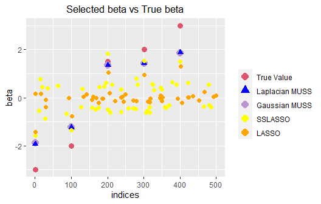

```r
Plot = ggplot()+
  geom_point(aes(x = true_indices, y = true_values, color="True Value",
                 shape="True Value"),size = 3)+
  geom_point(aes(x = muss_G$beta_indices, y = muss_G$beta_values,
                 color="Gaussian MUSS",shape="Gaussian MUSS"),size = 4)+
  geom_point(aes(x = muss_L$beta_indices, y = muss_L$beta_values,
                 color="Laplacian MUSS",shape="Laplacian MUSS"),size = 2.5)+
  geom_point(aes(x = sslasso_indices, y = sslasso_value,
                 color="SSLASSO",shape="SSLASSO"),size = 2)+
  geom_point(aes(x = lasso_indices, y = lasso_value,
                 color="LASSO",shape="LASSO"),size = 2)+
  scale_color_manual("", values = c("True Value" = "10A19D", "Laplacian MUSS" = "blue",
                                    "Gaussian MUSS" = "#BA94D1", "SSLASSO" = "yellow",
                                    "LASSO" = "orange"))+
  scale_shape_manual("",values = c("True Value" = 16, "Laplacian MUSS" = 17,
                                   "Gaussian MUSS" = 16,"SSLASSO" = 16,
                                   "LASSO" = 16))+
  xlab("indices")+ylab("beta")+
  labs(title ="Selected beta vs True beta")+
  theme(plot.title = element_text(size=13,hjust=0.5))

Plot
```

Paths of parameters can be obtained from the `pathPlot`. The default choice is `beta`. If the prior is chosen to be `Gaussian`, then the threshold at each spike parameter will be shown as the blue dashed line, as the algorithm with `Gaussian` prior cannot shrink the coefficients to zero automatically. The brown line stands for paths of finally selected regression parameters. From right to left, with the decreasing of spike parameter, values of coefficients tend to be stabilized.

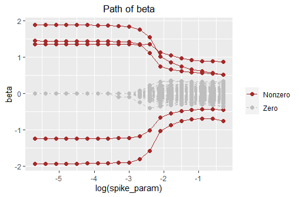

```r
pathPlot(muss_L)
```

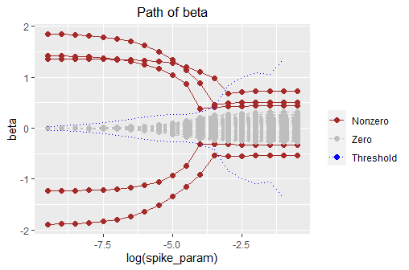

```r
pathPlot(muss_G)
```

And the paths of $\theta$ and $\sigma$ can also be obtained if specified.

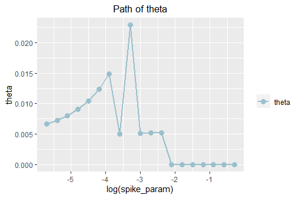

```r
pathPlot(muss_L,path_of = "theta")
```

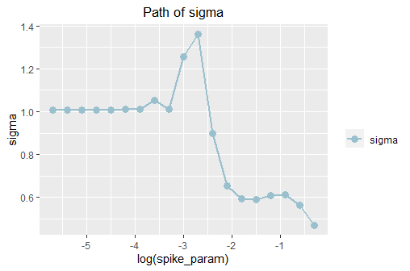

```r
pathPlot(muss_L,path_of = "sigma")
```

If `return_g = TRUE`, then according to the returned `g_List`, we can draw plots for `g` over iterations for each specific `spike_param` with function `gPlot`. One must specify the value of `spike_param` (a single value) to obtain the plot and it must be from `spike_params` used in `MUSS`. If default `spike_params` is used in `MUSS`, one can check its value by calling `$spike_params` from the returned object.

From the plot below, we can check that the value of $g$ is increasing over iterations.

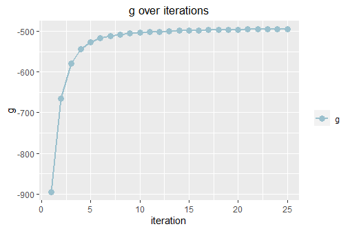

```r
gPlot(muss_L, spike_param = muss_L$spike_params[1])
```

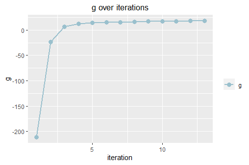

```r
gPlot(muss_L, spike_param = muss_L$spike_params[5])
```

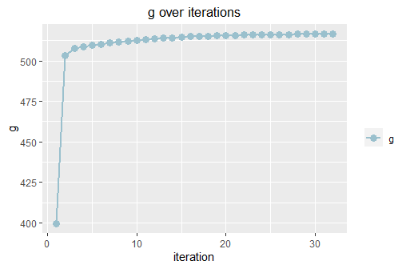

```r
gPlot(muss_L, spike_param = muss_L$spike_params[9])
```

## References

Ročková, Veronika, and Edward I. George. 2014. “EMVS: The EM Approach to Bayesian Variable Selection.” *Journal of the American Statistical Association* 109 (506): 828–46. https://doi.org/10.1080/01621459.2013.869223.

———. 2018. “The Spike-and-Slab LASSO.” *Journal of the American Statistical Association* 113 (521): 431–44. https://doi.org/10.1080/01621459.2016.1260469.